# Project Python Foundations: FoodHub Data Analysis

## Bi variate analysis

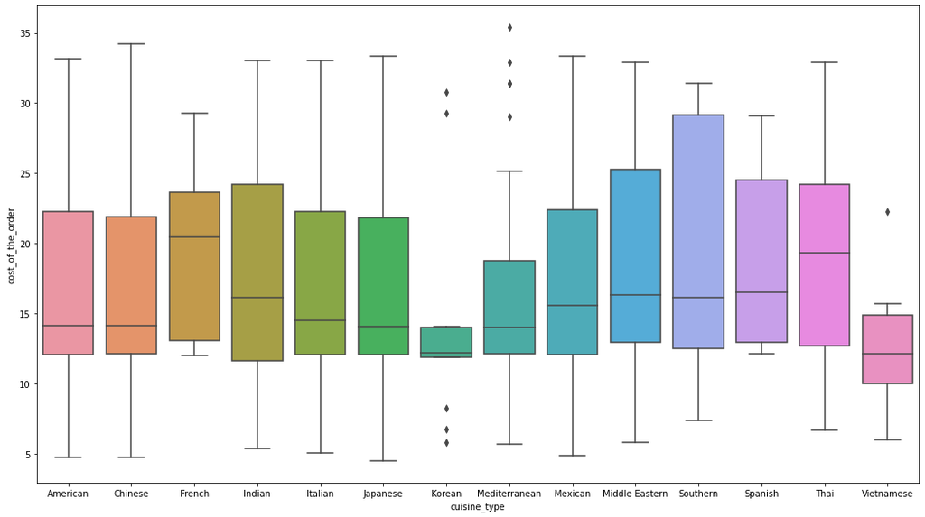

```python
# Relation between cusine type and cost of the order
plt.figure(figsize=(18,10))
sns.boxplot(x ='cuisine_type', y='cost_of_the_order',data = df)
```

#### Observation : Above plot shows relation between cusine_type and cost of the order.

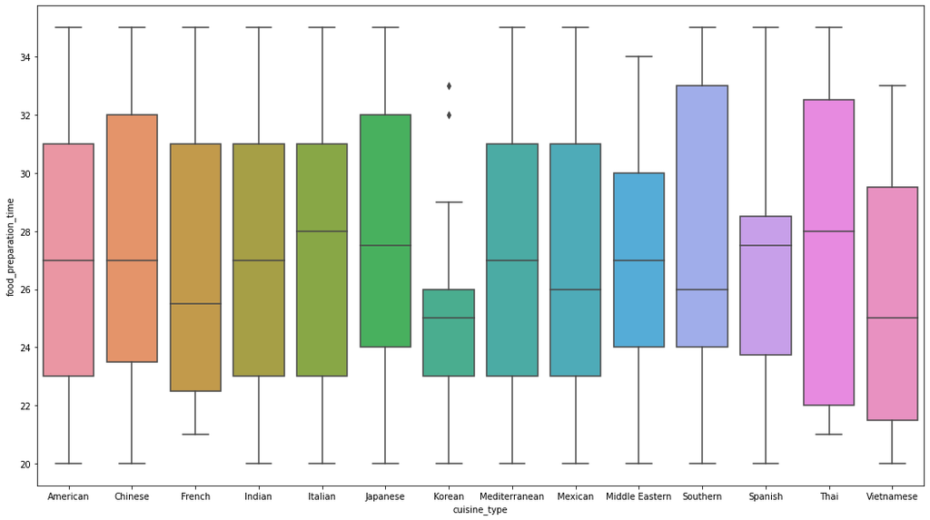

```python
# Relation between cusine type and food prep time
plt.figure(figsize=(18,10))
sns.boxplot(x ='cuisine_type', y='food_preparation_time',data = df)
```

#### Observation: Above plot shows relation between cuisine_type and Food Preparation time

1. The avg food prep time for most cuisines range between 24 to 28 minutes.
2. The lowest food prep time is around 20 minutes observed in most of the cuisines.
3. The highest food prep time is 30 minutes and above across most of the cuisines.

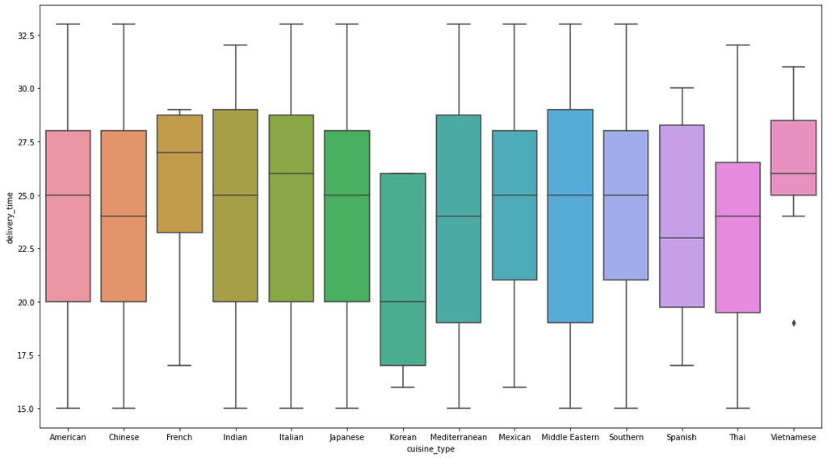

```python
# Relation between cusine type and delivery time
plt.figure(figsize=(18,10))
sns.boxplot(x ='cuisine_type', y='delivery_time',data = df)
```

#### Observation : Above plot shows relation between cuisine_type and Delivery time

1. The lowest delivery time observed is 15 minutes in most of the restaurants.
2. Maximum delivery time is around 33 minutes observed in most of the restarants.
3. Avg dev time ranges from 23 to 26 minutes for most of the restaurants.

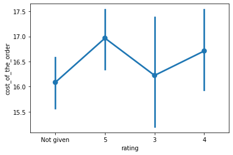

```python
#relation between rating and cost of the order

sns.pointplot(x= 'rating', y = 'cost_of_the_order', data = df)
```

### Observation:

1. Orders with a avg cost of 17 dollars or orders ranging from 16 to 17.5 dollars has 5 rating

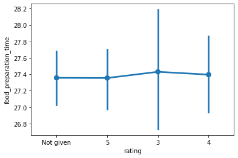

```python
#relation between rating and food prep time
sns.pointplot( x = 'rating', y = 'food_preparation_time', data = df)
```

### Observation:

1. Not much of a difference in rating with regards to food_prep time but the orders around 27 minutes has a good 5 rating

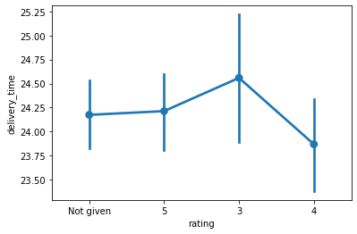

```python
#relation between rating and delivery time
sns.pointplot(x = 'rating', y = 'delivery_time', data = df)
```

### Observation:

1. Most preferred or high rated Avg delivery time for orders is around 24 minutes

## Multi variate Analysis

### Multi variate Analysis basis on Day of the week

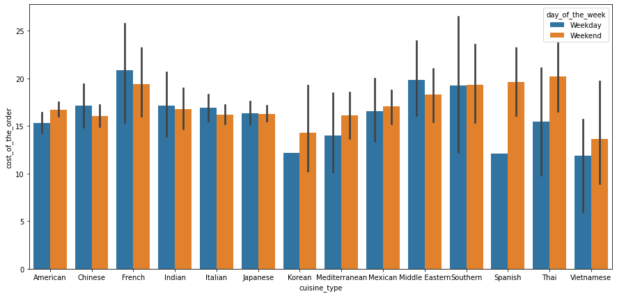

```python
# Relation between cuisine type and cost of the order basis on day of the week
plt.figure(figsize=(15,7))
sns.barplot( x= 'cuisine_type', y = 'cost_of_the_order' , data = df, hue = 'day_of_the_week' )
```

#### Observation : Above plot shows relation between cuisine type ,Cost of the Order and Day of the week

1. There is not much of a visible difference to be observed in the cost of the order during the Day of the week .
2. However, Spanish,Thai and Vietnamese show a huge variance during the weekends.

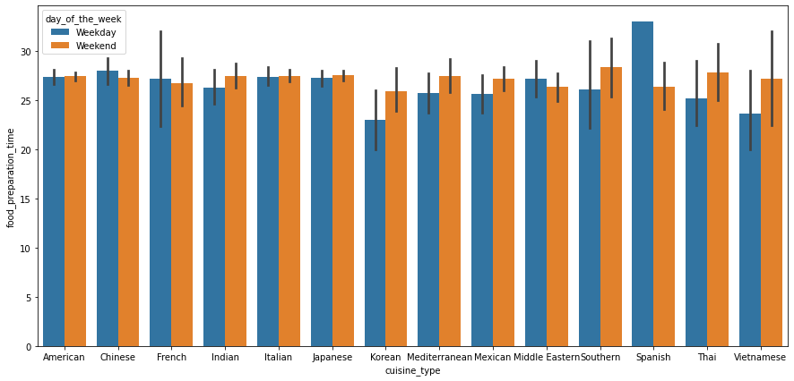

```python
# Relation between cuisine type and food prep time basis on day of the week
plt.figure(figsize=(15,7))
sns.barplot( x= 'cuisine_type', y = 'food_preparation_time' , data = df, hue = 'day_of_the_week' )
```

#### Observation : Above plot shows relation between cuisine type , food prep time and Day of the week

1. It is a clear observation that there is not much of a difference in food prep time during the Day of the week across most of the cuisines.
2. However, spanish cuisine shows a high food prep time during the weekdays.
3. But, Overall weekends do show a little higher food prep time when compared to the weekdays across most of the cuisines.

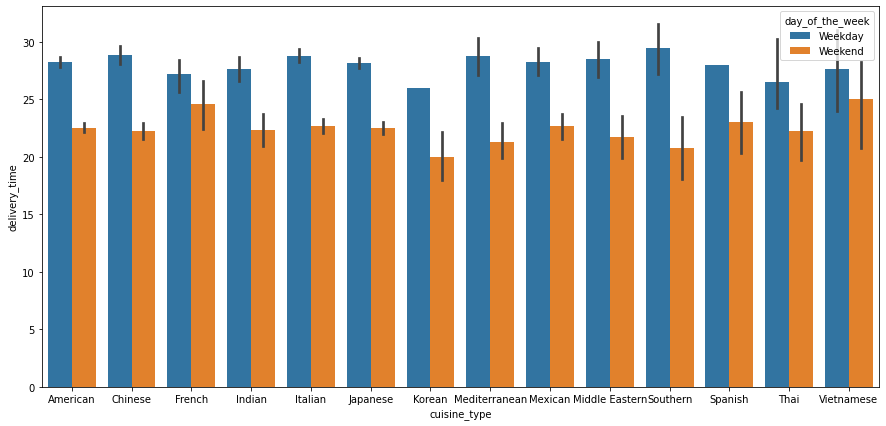

```python
# Relation between cuisine type and delivery time basis on day of the week
plt.figure(figsize=(15,7))
sns.barplot( x= 'cuisine_type', y = 'delivery_time' , data = df, hue = 'day_of_the_week' )
```

#### Observation : Above plot shows relation between cuisine type , Delivery time and Day of the week

1. It is very clear that Delivery time is higher on weekdays compared to the weekends across all the cuisines.

### Multi variate Analysis basis on Ratings

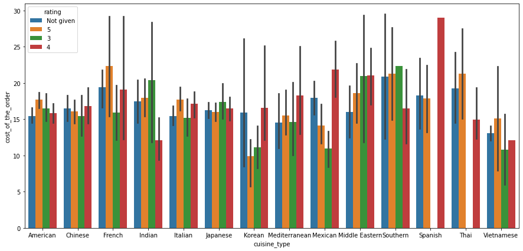

```python
# Relation between cuisine type and cost of the order basis on rating
plt.figure(figsize=(15,7))
sns.barplot( x= 'cuisine_type', y = 'cost_of_the_order' , data = df, hue = 'rating' )
```

#### Observstion: Rating on basis of cost of the order

1. cuisines such as french, Thai , vietnamese and American has a good 5 rating.
2. Cuisines such as Indian, japanese and southern has a higher 3 rating.

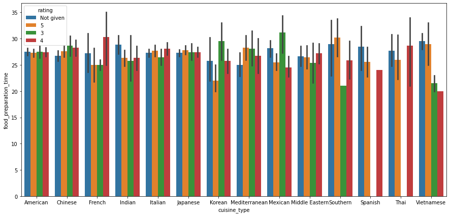

```python
# Relation between cuisine type and food prep time basis on day of the week
plt.figure(figsize=(15,7))
sns.barplot( x= 'cuisine_type', y = 'food_preparation_time' , data = df, hue = 'rating' )
```

#### Observation:Rating on basis of food preparation time

1. cuisines such as korean and mexican has very low rating
2. most of the restaurants show a stable rating ranging from 3 to 5
3. vietnamese again has a good 5 rating also has a highest not rated orders

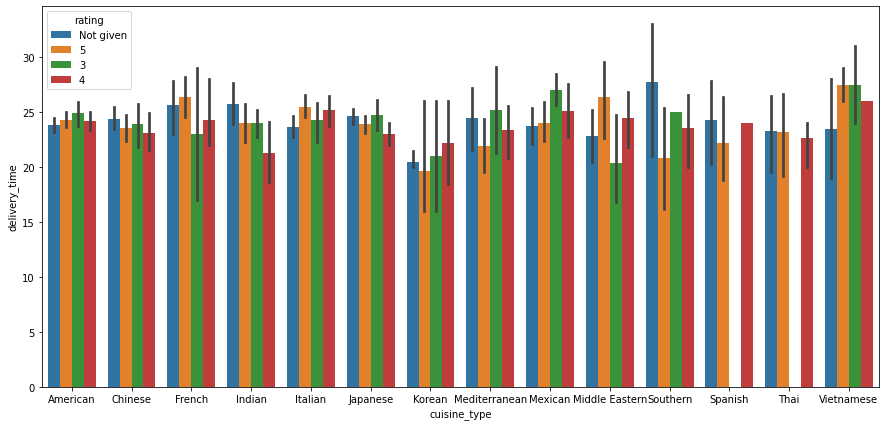

```python
# Relation between cuisine type and delivery time basis on day of the week
plt.figure(figsize=(15,7))
sns.barplot( x= 'cuisine_type', y = 'delivery_time' , data = df, hue = 'rating' )
```

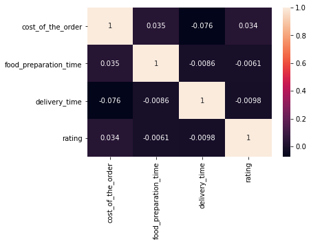

```python
# Map showing a correlation between the numerical variables

numeric = ['cost_of_the_order', 'food_preparation_time','delivery_time', 'rating']

corr = df_rating[numeric].corr()

sns.heatmap(corr, annot=True)
```